# Food Image Classification (Food101 Dataset)

## Problem Statement

Food logging and dietary analysis are important tools for individuals and healthcare professionals to monitor and manage nutrition and health. However, manually logging food intake can be time-consuming and error-prone, leading to inaccurate analysis and suboptimal outcomes. Recent advances in computer vision and deep learning have opened up new opportunities to automate the process of food logging by using image classification techniques to identify and categorize different types of food items based on their visual features.

Therefore, the goal of this project is to develop an image classification model that can identify various types of food items from images. This model is trained on the Food101 dataset (https://www.kaggle.com/datasets/kmader/food41), that consists of 101 categories of dishes such as beignets, Chicken Wings, Chocolate Mousse, Falafel, Macaroni And Cheese among others. The dataset includes over 1000 images for each category. The models use prominent image classification transformers such as ResNet50 and EfficientNet, data augmentation techniques and transfomer tweaking to learn from the visual features of the images, such as color, texture, shape, and context, to accurately classify the food items.

### Future Scope

The resulting food image classification model can be integrated into a mobile or web-based application, where users can take pictures of their meals, and the application can automatically identify and log the food items, along with their nutritional information. This can greatly improve the efficiency and accuracy of food logging and dietary analysis, helping individuals make better-informed food choices and healthcare professionals to provide more personalized and effective nutritional advice.

## Dataset

The dataset for this problem is taken from the following link: https://www.kaggle.com/datasets/kmader/food41. As the name Food101 suggests, the dataset contains 101 categories of food dishes including various dishes from contemporary dishes like Peking Duck, Foie Gras, Fillet Mignon, Eggs Benedict, Hot Dogs, Lobster Bisque to traditional dishes like Greek Salad, Guacamole, Hummus, Pho, Sashimi, Sushi etc. The dataset contains 1000 images for each food category, that totals to 101k images. The dataset was populated by FoodSpotting.

## Code

### Importing packages

```python
import tensorflow as tf                                                 # TensorFlow
from tensorflow import keras as k                                       # Keras
from tensorflow.keras.preprocessing.image import ImageDataGenerator     # ImageDataGenerator: Generate batches of tensor image data with real-time data augmentation.
import tensorflow.keras.layers as layers                                # keras.layers: Used to import various layers for building neural networks such as Flatten, Dense, Conv2D etc.
from tensorflow.keras.models import Sequential                          # models.Sequential: Used to create a sequential model i.e. A neural network model with plain stack of layers.
import matplotlib.pyplot as plt                                         # PyPlot: Used to plot the functions and graphs i.e. Accuracy and Loss curves.
import tensorflow_hub as hub                                            # Tensorflow Hub: Used to download and load pretrained models.
from datetime import datetime

from tensorflow.keras.preprocessing.image import ImageDataGenerator
from tensorflow.keras.applications.mobilenet_v2 import MobileNetV2
from tensorflow.keras import Sequential
from tensorflow.keras.layers import Dense, Dropout, GlobalAveragePooling2D
from tensorflow.keras.optimizers import Adam
from tensorflow.keras.callbacks import ReduceLROnPlateau, EarlyStopping
```

### Helper function to plot accuracy and loss curves

```python
def plot_result_curves(history):
    """
    Returns separate loss curves for training and validation metrics.
    Args:
      history: TensorFlow model History object (see: https://www.tensorflow.org/api_docs/python/tf/keras/callbacks/History)
    """
    loss = history.history['loss']
    val_loss = history.history['val_loss']

    accuracy = history.history['accuracy']
    val_accuracy = history.history['val_accuracy']

    epochs = range(len(history.history['loss']))

    # Plot loss
    plt.plot(epochs, loss, label='training_loss')
    plt.plot(epochs, val_loss, label='val_loss')
    plt.title('Loss')
    plt.xlabel('Epochs')
    plt.legend()

    # Plot accuracy
    plt.figure()
    plt.plot(epochs, accuracy, label='training_accuracy')
    plt.plot(epochs, val_accuracy, label='val_accuracy')
    plt.title('Accuracy')
    plt.xlabel('Epochs')
    plt.legend()
```

### Preparing data

We initialize the ImageDataGenerator object with rescale 1./255 and validation split of 0.2.

**Rescale**: Converts the pixels in range [0,255] to range [0,1]. This process is also called Normalizing the input. Scaling every images to the same range [0,1] will make images contributes more evenly to the total loss and removes bias from the model.

**Validation split** : The images are split into 80% training and 20% validation images

```python
datagen = ImageDataGenerator(rescale = 1./255, validation_split = 0.2)
```

```python
train_data = datagen.flow_from_directory('input/', target_size = (250,250), batch_size = 32, class_mode = 'categorical',
                                        subset = 'training') # Creating the training dataset

val_data = datagen.flow_from_directory('input/', target_size = (250,250), batch_size = 32, class_mode = 'categorical',
                                        subset = 'validation') # Creating the validation dataset
```

```
Found 80800 images belonging to 101 classes.
Found 20200 images belonging to 101 classes.
```

We have separated 80,800 images for the training set and 20,200 images for the validation set, totaling upto 101,000 images.

## Project - 1

### Model Building

#### Model 1: ResNet50 V2

ResNet50 is a deep convolutional neural network architecture that was introduced by Microsoft researchers in 2015. The name "ResNet" stands for "Residual Network" and refers to the use of residual connections, which allow for easier training of very deep neural networks.

The ResNet50 architecture consists of 50 layers, including a combination of convolutional, pooling, and fully connected layers. It is based on the concept of residual learning, where each block of layers contains a shortcut connection that adds the input of the block to its output. This allows the network to learn residual functions, i.e., the difference between the input and the output, rather than trying to directly learn the desired output.

```python
ResNet_V2_50 = 'https://tfhub.dev/google/imagenet/resnet_v2_50/classification/5' # Declaring the path to the model.
```

In this model, we are using the ResNetV2 model from TensorFlow hub. The trainable parameter of the ResNetV2 model is set to False, so that the weigts and biases of the models remain fixed while training.

We get the output of the ResNetV2 model in the final Dense layer with 101 neurons, representing the number of classes in the dataset. It uses the softmax activation function since this is a multiclass classification problem.

### Testing ResNet50 with data

To compare the performance of CNN at different stages, we test the performance of the original (un-tuned) ResNet50 model on the Food101 dataset. Later, we will compare the test accuracy of the final model.

```python
model_ResNet_test = tf.keras.Sequential([
    hub.KerasLayer(ResNet_V2_50, trainable = False, input_shape = (64,64,3), name = 'Resnet_V2_50'), # ResNet_V2_50 Layer
    tf.keras.layers.Dense(101, activation = 'softmax', name = 'Output_layer')                        # Dense layer for final output
])

model_ResNet_test.compile(
    optimizer = tf.keras.optimizers.Adam(),           # Adam optimizer with learning rate 0.001
    loss = tf.keras.losses.CategoricalCrossentropy(), # Categorical crossentropy loss: Since the output label is assigned one-hot category encoding value in form of 0s and 1.
    metrics = ['accuracy']                            # Accuracy metric to be used for model evaluation
)

model_ResNet_test.summary()

model_ResNet_test.evaluate(train_data)
```

```
Model: "sequential_4"
_________________________________________________________________
 Layer (type)                Output Shape              Param #
=================================================================
 Resnet_V2_50 (KerasLayer)   (None, 1001)              25615849

 Output_layer (Dense)        (None, 101)               101202

=================================================================
Total params: 25,717,051
Trainable params: 101,202
Non-trainable params: 25,615,849
_________________________________________________________________
```

```
[6.604486465454102, 0.011386138387024403]
```

We observe that the accuracy of the untuned ResNet_V2_50 Model is only 1% which is understandable since the model was originally trained for open domain rather than a specialized subset of data.

### Fine-tuning ResNet CNN Model

```python
model_ResNet = tf.keras.Sequential([
    hub.KerasLayer(ResNet_V2_50, trainable = False, input_shape = (64,64,3), name = 'Resnet_V2_50'), # ResNet_V2_50 Layer
    tf.keras.layers.Dense(101, activation = 'softmax', name = 'Output_layer')                        # Dense layer for final output
])

model_ResNet.compile(
    optimizer = tf.keras.optimizers.Adam(),           # Adam optimizer with learning rate 0.001
    loss = tf.keras.losses.CategoricalCrossentropy(), # Categorical crossentropy loss: Since the output label is assigned one-hot category encoding value in form of 0s and 1.
    metrics = ['accuracy']                            # Accuracy metric to be used for model evaluation
)
```

```python
model_ResNet.summary() # Printing the model summary
```

```
Model: "sequential"
_________________________________________________________________
 Layer (type)                Output Shape              Param #
=================================================================
 Resnet_V2_50 (KerasLayer)   (None, 1001)              25615849

 Output_layer (Dense)        (None, 101)               101202

=================================================================
Total params: 25,717,051
Trainable params: 101,202
Non-trainable params: 25,615,849
_________________________________________________________________
```

```python
resnet_model_history = model_ResNet.fit(train_data, validation_data=val_data, epochs=15, verbose=1) # Training the model
```

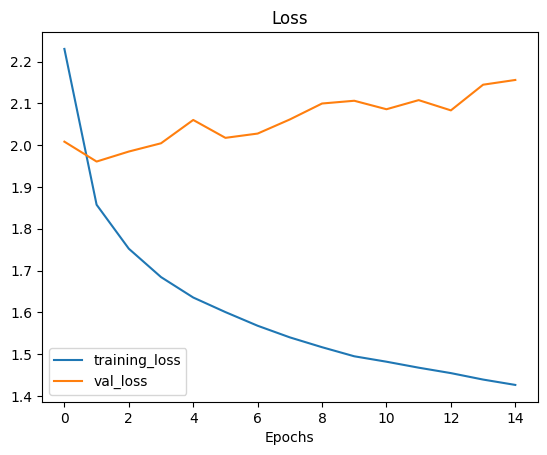

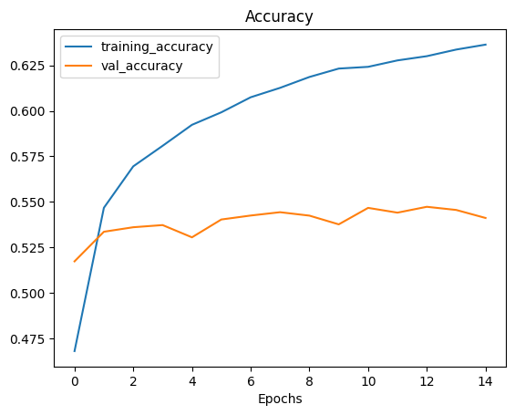

```python
plot_result_curves(resnet_model_history)
```

```python
model_ResNet.save('models/resnet50.h5')
```

Model 1 gives out a best training accuracy of 0.6364 i.e. 63.64% and the best validation accuracy of 0.5411 i.e. 54.11%. I am sure we can do better than that.

### Model 2: EfficientNet-B0

### EfficientNet

EfficientNet is a deep convolutional neural network architecture that was introduced by Google researchers in 2019. The name "EfficientNet" refers to the fact that it achieves state-of-the-art performance on a variety of computer vision tasks while being more computationally efficient than previous models.

EfficientNet is based on a novel approach to neural architecture search, which involves optimizing the scaling of the model's width, depth, and resolution to achieve better performance. Specifically, the researchers used a compound scaling method, where they systematically increased the width, depth, and resolution of the base network while keeping the number of parameters and FLOPs (floating-point operations) constant.

```python
EfficientNet = "https://tfhub.dev/google/efficientnet/b0/classification/1" # Declaring the path for the EfficientNet model
```

In this model, we are using the EfficientNet model from TensorFlow hub. The trainable parameter of the EfficientNet model is set to False, so that the weigts and biases of the models remain fixed while training.

We get the output of the EfficientNet model in the final Dense layer with 101 neurons, representing the number of classes in the dataset, same as model 1.

```python
model_Efficientnet_test = tf.keras.Sequential([
    hub.KerasLayer(EfficientNet, trainable = False, input_shape = (64,64,3), name = 'Resnet_V2_50'), # ResNet_V2_50 Layer
    tf.keras.layers.Dense(101, activation = 'softmax', name = 'Output_layer')                        # Dense layer for final output
])

model_Efficientnet_test.compile(
    optimizer = tf.keras.optimizers.Adam(),           # Adam optimizer with learning rate 0.001
    loss = tf.keras.losses.CategoricalCrossentropy(), # Categorical crossentropy loss: Since the output label is assigned one-hot category encoding value in form of 0s and 1.
    metrics = ['accuracy']                            # Accuracy metric to be used for model evaluation
)

model_Efficientnet_test.summary()

model_Efficientnet_test.evaluate(train_data)
```

```
Model: "sequential_5"
_________________________________________________________________
 Layer (type)                Output Shape              Param #
=================================================================
 Resnet_V2_50 (KerasLayer)   (None, 1000)              5330564

 Output_layer (Dense)        (None, 101)               101101

=================================================================
Total params: 5,431,665
Trainable params: 101,101
Non-trainable params: 5,330,564
_________________________________________________________________
```

```
[5.498457431793213, 0.009405940771102905]
```

Untuned EfficientNet-B0 model only gives out 0.94% accuracy on the Food101 dataset.

### Fine-tuning the EfficientNet-B0 model

```python
model_Efficientnet = tf.keras.Sequential([
    hub.KerasLayer(EfficientNet, trainable = False, input_shape = (250,250,3), name = 'EfficientNet_B0'), # EfficientNet_B0 Layer
    tf.keras.layers.Dense(101, activation = 'softmax', name = 'Output_layer')                             # Dense layer for output
])

model_Efficientnet.compile(
    optimizer = tf.keras.optimizers.Adam(),           # Adam optimizer with learning rate 0.001
    loss = tf.keras.losses.CategoricalCrossentropy(), # Categorical crossentropy loss: Since the output label is assigned one-hot category encoding value in form of 0s and 1.
    metrics = ['accuracy']                            # Accuracy metric to be used for model evaluation
)
```

```python
model_Efficientnet.summary() # Printing the model summary
```

```
Model: "sequential_3"
_________________________________________________________________
 Layer (type)                Output Shape              Param #
=================================================================
 EfficientNet_B0 (KerasLayer  (None, 1000)             5330564
 )

 Output_layer (Dense)        (None, 101)               101101

=================================================================
Total params: 5,431,665
Trainable params: 101,101
Non-trainable params: 5,330,564
_________________________________________________________________
```

```python
efficientnet_model_history = model_Efficientnet.fit(train_data, validation_data=val_data, epochs = 15, verbose = 1) # Training the model
```

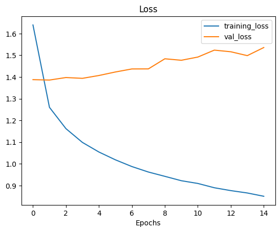

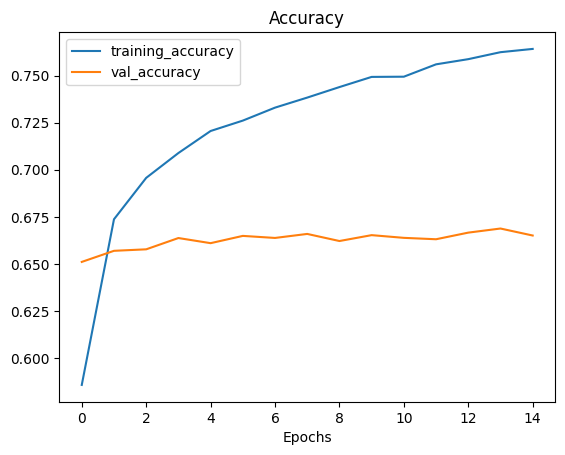

```python
plot_result_curves(efficientnet_model_history)
```

Model 2 gives out a best training accuracy of 0.7641 i.e. 76.41% and the best validation accuracy of 0.6651 i.e. 66.51%. As we can see, the EfficientNet-B0 model performs much better than the ResNet50 model for our problem.

```python
model_Efficientnet.save('models/EfficientNet_B0.h5')
```

### Model 3: EfficientNet-B0 model with Data Augmentation

### Data Augmentation

Data augmentation is a technique used to increase the size and diversity of a training dataset for image classification problems. It involves applying a variety of image transformations to the original images, resulting in new images that are similar but not identical to the original ones. The purpose of data augmentation is to increase the robustness and generalization capability of a machine learning model by exposing it to a wider variety of input data. Data Augmentation helps improve the generalization ability of a machine learning model.

These are the techniques used for Data Augmentation in this project:

1. RandomRotation: We use the factor of 0.2 to define the maximum rotation angle i.e. 0.2 * 2pi = 0.2 * 360 = 72 degrees. Therefore, the range of rotation angle will vary from -72 degrees to 72 degrees.
2. RandomZoom: We use the factor of 0.2 to define the zoom range i.e. Zoomed in by 20% or Zoomed out by 20%.
3. RandomHeight: We use the factor of 0.2 to define the range of height i.e. from 120% to 80% of the original image height.
4. RandomWidth: We use the factor of 0.2 to define the range of width i.e. from 120% to 80% of the original image width.
5. RandomFlip: We use the factor horizontal instead of horizontal_and_vertical since adding a vertical flip might make an image unnatural, and since most of the images received by the model for testing would not be vertically inverted.

```python
data_augmentation = Sequential([
    layers.RandomRotation(0.2),      # RandomRotation: A preprocessing layer which randomly rotates images during training.
    layers.RandomZoom(0.2),          # RandomZoom:     A preprocessing layer which randomly zooms images during training.
    layers.RandomHeight(0.2),        # RandomHeight:   A preprocessing layer which randomly changes the height of images during training.
    layers.RandomWidth(0.2),         # RandomWidth:    A preprocessing layer which randomly changes the width of images during training.
    layers.RandomFlip("horizontal"), # RandomFlip:     A preprocessing layer which randomly flips images during training.
], name="data_augmentation") # Defining the data augmentation layer
```

### Fine-tuning the EfficientNet-B0 model with Data Augmentation

```python
model_Efficientnet_DA = tf.keras.Sequential([
    layers.Input(shape=(250, 250, 3), name="input_layer"),                     # Input layer with shape (250, 250, 3)
    data_augmentation,                                                         # Data augmentation layer with image transformations
    hub.KerasLayer(EfficientNet, trainable = False, name = 'Efficientnet_b0'), # EfficientNet model layer with fixed weights and biases
    layers.Flatten(name="flatten"),                                            # Flatten layer
    tf.keras.layers.Dense(101, activation = 'softmax', name = 'Output_layer')  # Output layer with 101 neurons
])
```

[output not shown]

[output not shown]

[output not shown]

[output not shown]

[output not shown]

[output not shown]

[output not shown]

[output not shown]

[output not shown]

[output not shown]

[output not shown]

[output not shown]

[output not shown]

[output not shown]

[output not shown]

[output not shown]

[output not shown]

[output not shown]

[output not shown]

[output not shown]

[output not shown]

[output not shown]

[output not shown]

[output not shown]

[output not shown]

[output not shown]

[output not shown]

[output not shown]

[output not shown]

[output not shown]

[output not shown]

[output not shown]

[output not shown]

[output not shown]

[output not shown]

[output not shown]

[output not shown]

[output not shown]

[output not shown]

[output not shown]

```python
model_Efficientnet_DA.compile(loss="categorical_crossentropy",         # Categorical crossentropy loss: Since the output label is assigned one-hot category encoding value in form of 0s and 1.
    optimizer=tf.keras.optimizers.Adam(learning_rate=0.0001),          # Adam optimizer with learning rate 0.0001
    metrics=["accuracy"])                                              # Accuracy metric to be used for model evaluation
```

```python
model_Efficientnet_DA.summary() # Printing the model summary
```

```
Model: "sequential_2"
_________________________________________________________________
 Layer (type)                Output Shape              Param #
=================================================================
 data_augmentation (Sequenti  (None, None, None, 3)    0
 al)

 Efficientnet_b0 (KerasLayer  (None, 1000)             5330564
 )

 flatten (Flatten)           (None, 1000)              0

 Output_layer (Dense)        (None, 101)               101101

=================================================================
Total params: 5,431,665
Trainable params: 101,101
Non-trainable params: 5,330,564
_________________________________________________________________
```

```python
model_Efficientnet_DA_Hist = model_Efficientnet_DA.fit(train_data, validation_data=val_data, epochs=15) # Training the model
```

[output not shown]

[output not shown]

[output not shown]

[output not shown]

[output not shown]

[output not shown]

[output not shown]

[output not shown]

[output not shown]

[output not shown]

[output not shown]

[output not shown]

[output not shown]

[output not shown]

[output not shown]

[output not shown]

[output not shown]

[output not shown]

[output not shown]

[output not shown]

[output not shown]

[output not shown]

[output not shown]

[output not shown]

[output not shown]

[output not shown]

[output not shown]

[output not shown]

[output not shown]

[output not shown]

[output not shown]

[output not shown]

[output not shown]

[output not shown]

[output not shown]

[output not shown]

[output not shown]

[output not shown]

[output not shown]

[output not shown]

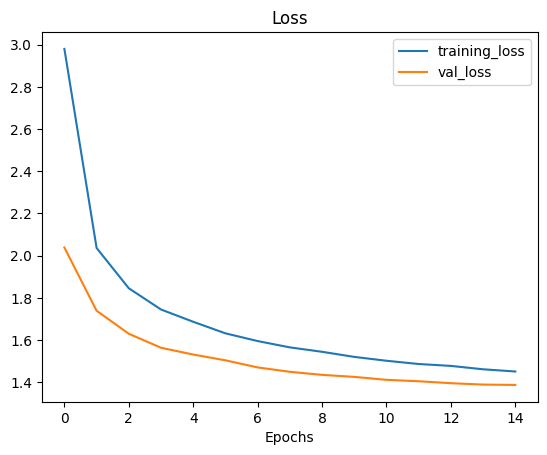

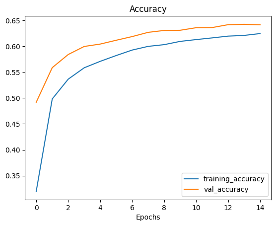

```python
plot_result_curves(model_Efficientnet_DA_Hist) # Plotting the result curves
```

Model 3 gives out a best training accuracy of 0.6246 i.e. 62.46% and the best validation accuracy of 0.6416 i.e. 64.16%. Although this model has not resulted in a better training accuracy as compared to Model 2, it is still a good model to use since it has been trained for transformed images. Therefore, this model is more general as comapared to Model 2.

We set some layers as trainable during fine-tuning so as to balance the trade-off between leveraging the pre-trained model's knowledge and adapting it to the new task or dataset. By freezing some layers, we can preserve the pre-trained model's ability to extract general features and patterns from the input data, which can be transferred to the new task or dataset.

```python
base_model = tf.keras.applications.EfficientNetB0(include_top=False)
base_model.trainable = False # Setting all the layers to non-trainable

for layer in base_model.layers[:-5]:
    layer.trainable = True # Setting last 5 layers to trainable

inputs = layers.Input(shape=(250, 250, 3), name="input_layer")            # Input layer with shape (250, 250, 3)
x = base_model(inputs)                                                    # EfficientNetB0 model layer with last 5 layers as trainable
x = layers.Flatten()(x)                                                   # Flatten layer
outputs = layers.Dense(101, activation="softmax", name="output_layer")(x) # Final output layer with 101 neurons

model = tf.keras.Model(inputs, outputs) # Building the model
```

```python
model.compile(loss="categorical_crossentropy",                         # Categorical crossentropy loss: Since the output label is assigned one-hot category encoding value in form of 0s and 1.
             optimizer=tf.keras.optimizers.Adam(learning_rate=0.0001), # Adam optimizer with learning rate 0.0001
             metrics=["accuracy"])                                     # Accuracy metric to be used for model evaluation
```

```python
model.summary() # Printing the model summary
```

```
Model: "model_2"
_________________________________________________________________
 Layer (type)                Output Shape              Param #
=================================================================
 input_layer (InputLayer)    [(None, 250, 250, 3)]     0

 efficientnetb0 (Functional)  (None, None, None, 1280)  4049571

 flatten_1 (Flatten)         (None, 62720)             0

 output_layer (Dense)        (None, 101)               6334821

=================================================================
Total params: 10,384,392
Trainable params: 6,334,821
Non-trainable params: 4,049,571
_________________________________________________________________
```

```python
model_history = model.fit(train_data, validation_data=val_data, epochs=15) # Training the model
```

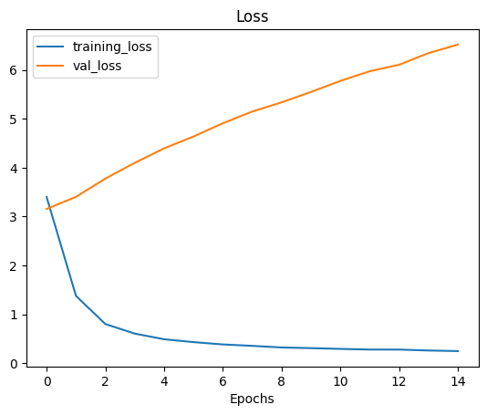

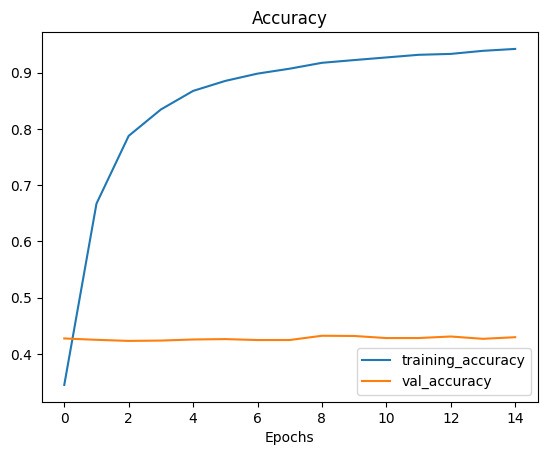

```python
plot_result_curves(model_history) # Plotting the result curves
```

Model 4 gives out a best training accuracy of 0.9423 i.e. 94.23% and the best validation accuracy of 0.4298 i.e. 42.98%. This model has resulted in a far better training accuracy. This means that the model is well trained on the training data. However, the validation accuracy is not as good as the training accuracy. It indicates that we have run into severe overfitting, where the model is not able to make a good prediction on the validation data.

```python
base_model = tf.keras.applications.EfficientNetB0(include_top=False)
base_model.trainable = False # Setting all the layers to non-trainable

for layer in base_model.layers[:-2]:
    layer.trainable = True # Setting last 2 layers to trainable

inputs = layers.Input(shape=(250, 250, 3), name="input_layer")            # Input layer with shape (250, 250, 3)
x = base_model(inputs)                                                    # EfficientNetB0 model layer with last 2 layers as trainable
x = layers.Flatten()(x)                                                   # Flatten layer
outputs = layers.Dense(101, activation="softmax", name="output_layer")(x) # Final output layer with 101 neurons

model = tf.keras.Model(inputs, outputs) # Building the model
```

```python
model.compile(loss="categorical_crossentropy",                         # Categorical crossentropy loss: Since the output label is assigned one-hot category encoding value in form of 0s and 1.
             optimizer=tf.keras.optimizers.Adam(learning_rate=0.0001), # Adam optimizer with learning rate 0.0001
             metrics=["accuracy"])                                     # Accuracy metric to be used for model evaluation

model.summary() # Printing the model summary
```

```
Model: "model_3"
_________________________________________________________________
 Layer (type)                Output Shape              Param #
=================================================================
 input_layer (InputLayer)    [(None, 250, 250, 3)]     0

 efficientnetb0 (Functional)  (None, None, None, 1280)  4049571

 flatten_2 (Flatten)         (None, 62720)             0

 output_layer (Dense)        (None, 101)               6334821

=================================================================
Total params: 10,384,392
Trainable params: 6,334,821
Non-trainable params: 4,049,571
_________________________________________________________________
```

```python
model_history_2 = model.fit(train_data, validation_data=val_data, epochs=15) # Training the model
```

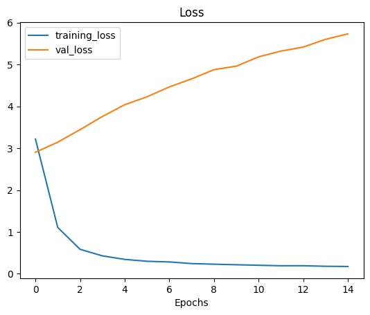

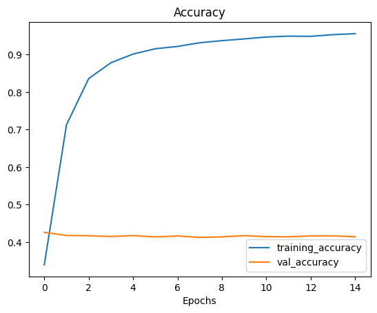

```python
plot_result_curves(model_history_2) # Plotting the result curves
```

### Comparison

```python
model.evaluate(val_data)
```

```
[5.7289252281188965, 0.4141584038734436]
```

#### We observe here that although the testing accuracy is not very good, the fine-tuned EfficientNet Model still performs very well as compared to the original untuned model.

### Conclusion

Following are the training and validation accuracies of the trained models

[output not shown]

We can conclude from here that EfficientNet_B0 is the most generally efficient model so far, since it has a good training accuracy and the best performance on the test set. However, it also indicates that setting last layers of the model to trainable can be useful for fine-tuning, considering we use measures to prevent overfitting. We can use techniques such as: Early Stopping, Dropout, or Weight Decay to prevent these situations from occurring.

## Project - 2

### Issue with the previous models

Overfitting is a common issue with machine learning models that occurs when a model is trained too well on the training data, to the point that it begins to fit the noise in the data rather than the underlying patterns. This means that the model becomes very accurate in predicting the training data but performs poorly on new data or test data, which is a problem as the primary goal of a machine learning model is to generalize well on unseen data.

Overfitting occurs when a model becomes too complex, and it tries to fit too closely to the training data, even capturing the random fluctuations and noise in the training data. This happens because the model is over-parameterized or because the model has been trained for too many iterations or epochs.

We observed in the previous models that the EfficientNet_B0 model gave the most optimal performance i.e. Training Accuracy of 76.41% and Validation Accuracy of 66.51%. However, most of the other configurations of the EfficientNet_B0 model showed significant overfitting with high training accuracies of 95% but validation accuracies of only 42%.

### Solutions

There are several ways to reduce overfitting in machine learning models. Some of these methods are:

1. **Dropout**: Dropout is a regularization technique where random neurons are dropped out or ignored during the training process. This helps to reduce the model's dependence on any single neuron and can reduce overfitting.
2. **Early Stopping**: Early stopping is a technique where the training process is stopped before the model starts to overfit. This is typically done by monitoring the model's performance on a validation set during the training process, and stopping the training when the performance starts to decrease.
3. **Data Augmentation**: Data augmentation involves increasing the amount of data available for training by creating new synthetic data based on the existing data. This can help to prevent overfitting by providing the model with a more diverse set of examples to learn from.

In the second part of the project, we will be using different techniques i.e. Adding additional layers, Dropout, Weight Decay, trying new models etc. to try to score higher accuracies.

### Trying new models and configurations

### Model 6: EfficientNet with 2 Dense layers

#### Model 6.1: EfficientNet model with Dense layers with linear activation function

```python
model_Efficientnet_Dense512_256 = tf.keras.Sequential([
    hub.KerasLayer(EfficientNet, trainable = False, input_shape = (250,250,3), name = 'EfficientNet_B0'), # EfficientNet_B0 Layer
    tf.keras.layers.Dense(512),                                                                           # Dense layer with 512 neurons
    tf.keras.layers.Dense(256),                                                                           # Dense layer with 256 neurons
    tf.keras.layers.Dense(101, activation = 'softmax', name = 'Output_layer')                             # Dense layer with 101 neurons for output
])

model_Efficientnet_Dense512_256.compile(
    optimizer = tf.keras.optimizers.Adam(),           # Adam optimizer with default learning rate 0.001
    loss = tf.keras.losses.CategoricalCrossentropy(), # Categorical crossentropy loss: Since the output label is assigned one-hot category encoding value in form of 0s and 1.
    metrics = ['accuracy']                            # Accuracy metric to be used for model evaluation
)

model_Efficientnet_Dense512_256.summary() # Printing the model summary

model_Efficientnet_Dense512_256_model_history = model_Efficientnet_Dense512_256.fit(train_data, validation_data=val_data, epochs = 10, verbose = 1) # Training the model
```

```
Model: "sequential_11"
_________________________________________________________________
 Layer (type)                Output Shape              Param #
=================================================================
 EfficientNet_B0 (KerasLayer  (None, 1000)             5330564
 )

 dense_24 (Dense)            (None, 512)               512512

 dense_25 (Dense)            (None, 256)               131328

 Output_layer (Dense)        (None, 101)               25957

=================================================================
Total params: 6,000,361
Trainable params: 669,797
Non-trainable params: 5,330,564
_________________________________________________________________
```

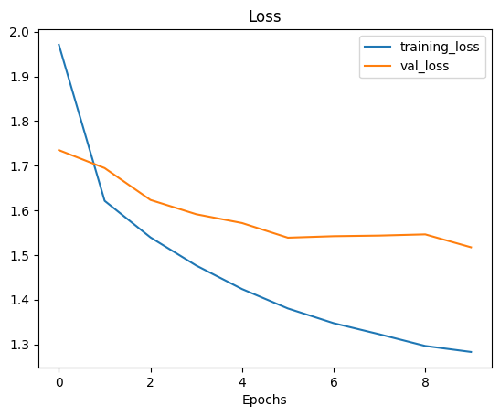

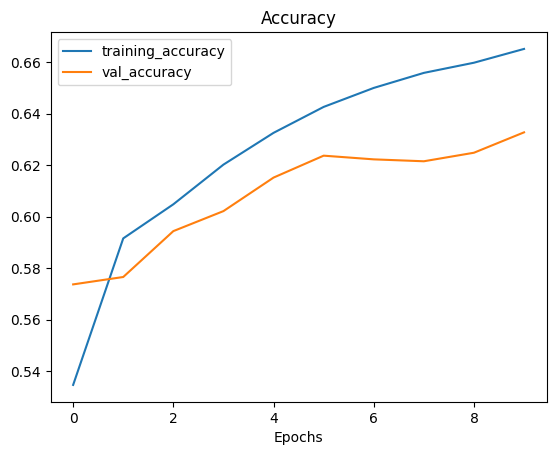

```python
plot_result_curves(model_Efficientnet_Dense512_256_model_history) # Plotting the result curves
```

#### **Observation**

As we can see, the EfficientNet model with two dense layer gave training accuracy of **66.51%** and validation accuracy of **63.27%**. Therefore, the EfficientNet_B0 model with two dense layers is certainly performing better than the ResNet_B0 model. However, it is still lagging behind the vanilla EfficientNet_B0 model that gave a training accuracy of **76.41%** and validation accuracy of **66.51%**. Hence, we conclude that the addition of the two dense layers does not improve the performance of the model.

#### Model 6.2: EfficientNet model with Dense layers with ReLU activation function

```python
model_Efficientnet_Dense512_256RELU = tf.keras.Sequential([
    hub.KerasLayer(EfficientNet, trainable = False, input_shape = (250,250,3), name = 'EfficientNet_B0'), # EfficientNet_B0 Layer
    tf.keras.layers.Dense(512, activation="relu"),                                                        # Dense layer with 512 neurons with ReLU activation
    tf.keras.layers.Dense(256, activation="relu"),                                                        # Dense layer with 256 neurons with ReLU activation
    tf.keras.layers.Dense(101, activation = 'softmax', name = 'Output_layer')                             # Dense layer with 101 neurons for output
])

model_Efficientnet_Dense512_256RELU.compile(
    optimizer = tf.keras.optimizers.Adam(),           # Adam optimizer with default learning rate 0.001
    loss = tf.keras.losses.CategoricalCrossentropy(), # Categorical crossentropy loss: Since the output label is assigned one-hot category encoding value in form of 0s and 1.
    metrics = ['accuracy']                            # Accuracy metric to be used for model evaluation
)

model_Efficientnet_Dense512_256RELU.summary() # Printing the model summary

model_Efficientnet_Dense512_256RELU_model_history = model_Efficientnet_Dense512_256RELU.fit(train_data, validation_data=val_data, epochs = 10, verbose = 1) # Training the model
```

```
Model: "sequential_35"
_________________________________________________________________
 Layer (type)                Output Shape              Param #
=================================================================
 EfficientNet_B0 (KerasLayer  (None, 1000)             5330564
 )

 dense_46 (Dense)            (None, 512)               512512

 dense_47 (Dense)            (None, 256)               131328

 Output_layer (Dense)        (None, 101)               25957

=================================================================
Total params: 6,000,361
Trainable params: 669,797
Non-trainable params: 5,330,564
_________________________________________________________________
```

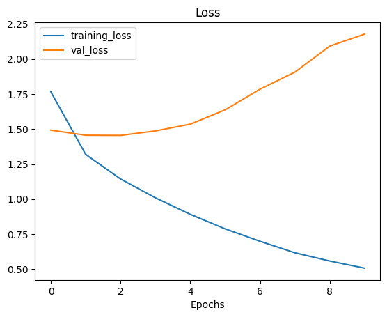

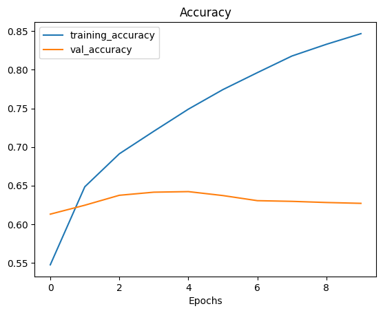

```python
plot_result_curves(model_Efficientnet_Dense512_256RELU_model_history)  # Plotting the result curves
```

#### **Observation**

We can observe that adding the ReLU activation function instead of the linear activation function significantly improves the training performance of the model. However, the validation accuracy of the model is not much affected.

### Model 7: EfficientNet with Dropout layers

Dropout is a regularization technique used in machine learning to prevent overfitting in neural networks. It is a simple and effective way to improve the generalization performance of a model and reduce the chances of overfitting.

The dropout technique involves randomly dropping out or "turning off" some neurons during training, so that they do not contribute to the forward or backward pass of the network. During each training iteration, a random subset of neurons is selected to be dropped out, with a certain probability of dropping out for each neuron.

For this model, we are going to try add two layers of Dropout after the EfficientNet layer, one with a dropout factor of 0.2 and 0.5 i.e. 20% and 50% of the neurons would be turned off.

#### Model 7.1: EfficientNet with Dropout of 0.2

```python
model_Efficientnet_Dropout20 = tf.keras.Sequential([
    hub.KerasLayer(EfficientNet, trainable = False, input_shape = (250,250,3), name = 'EfficientNet_B0'), # EfficientNet_B0 Layer
    tf.keras.layers.Dropout(0.2),                                                                         # Dropout layer with 0.2 dropout factor
    tf.keras.layers.Dense(101, activation = 'softmax', name = 'Output_layer')                             # Dense layer for output
])

model_Efficientnet_Dropout20.compile(
    optimizer = tf.keras.optimizers.Adam(),           # Adam optimizer with learning rate 0.001
    loss = tf.keras.losses.CategoricalCrossentropy(), # Categorical crossentropy loss: Since the output label is assigned one-hot category encoding value in form of 0s and 1.
    metrics = ['accuracy']                            # Accuracy metric to be used for model evaluation
)


model_Efficientnet_Dropout20.summary() # Printing the model summary

efficientnet_Dropout20_model_history = model_Efficientnet_Dropout20.fit(train_data, validation_data=val_data, epochs = 8, verbose = 1) # Training the model
```

```
Model: "sequential_30"
_________________________________________________________________
 Layer (type)                Output Shape              Param #
=================================================================
 EfficientNet_B0 (KerasLayer  (None, 1000)             5330564
 )

 dropout_28 (Dropout)        (None, 1000)              0

 Output_layer (Dense)        (None, 101)               101101

=================================================================
Total params: 5,431,665
Trainable params: 101,101
Non-trainable params: 5,330,564
_________________________________________________________________
```

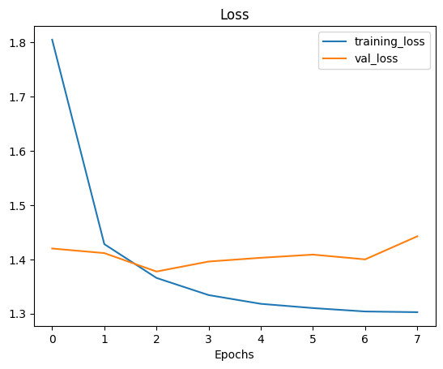

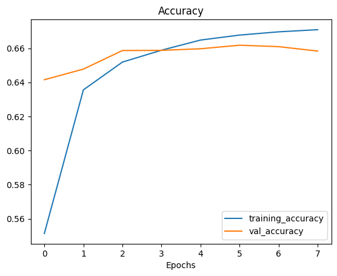

```python
plot_result_curves(efficientnet_Dropout20_model_history) # Plotting the result curves
```

#### Model 7.2: EfficientNet with Dropout of 0.5

```python
model_Efficientnet_Dropout50 = tf.keras.Sequential([
    hub.KerasLayer(EfficientNet, trainable = False, input_shape = (250,250,3), name = 'EfficientNet_B0'), # EfficientNet_B0 Layer
    tf.keras.layers.Dropout(0.5),                                                                         # Dropout layer with 0.5 dropout factor
    tf.keras.layers.Dense(101, activation = 'softmax', name = 'Output_layer')                             # Dense layer for output
])

model_Efficientnet_Dropout50.compile(
    optimizer = tf.keras.optimizers.Adam(),           # Adam optimizer with learning rate 0.001
    loss = tf.keras.losses.CategoricalCrossentropy(), # Categorical crossentropy loss: Since the output label is assigned one-hot category encoding value in form of 0s and 1.
    metrics = ['accuracy']                            # Accuracy metric to be used for model evaluation
)
model_Efficientnet_Dropout50.summary() # Printing the model summary

model_Efficientnet_Dropout50_model_history = model_Efficientnet_Dropout50.fit(train_data, validation_data=val_data, epochs = 10, verbose = 1) # Training the model
```

```
Model: "sequential_31"
_________________________________________________________________
 Layer (type)                Output Shape              Param #
=================================================================
 EfficientNet_B0 (KerasLayer  (None, 1000)             5330564
 )

 dropout_29 (Dropout)        (None, 1000)              0

 Output_layer (Dense)        (None, 101)               101101

=================================================================
Total params: 5,431,665
Trainable params: 101,101
Non-trainable params: 5,330,564
_________________________________________________________________
```

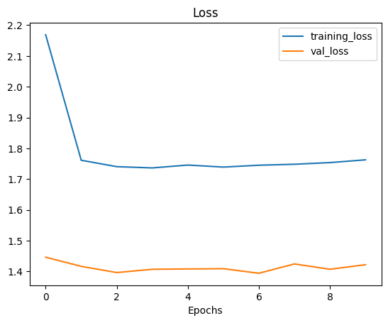

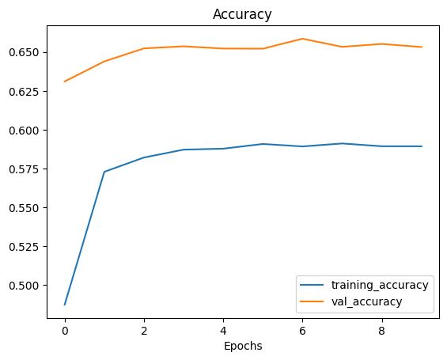

```python
plot_result_curves(model_Efficientnet_Dropout50_model_history) # Plotting the results curves
```

EfficientNet with dropout factor **0.2** ---> Training accuracy of **67.09%** and validation accuracy of **65.84%**

EfficientNet with dropout factor **0.5** ---> Training accuracy of **58.93%** and validation accuracy of **65.32%**

#### **Observation**

The EfficientNet model with a dropout factor of 0.2 performs much better than the model with a dropout factor of 0.5, with a difference in training accuracy of approximately **9%**. However, both of these models perform almost exactly the same when it comes to validation accuracy. And since the original EfficientNet model had a validation accuracy of 66.51%, it says that only adding a single layer of Dropout may not be sufficient to significantly improve the accuracy of the model. However, it also indicates that robustness of the Dropout technique when it is added with additional layers.

### Model 8: EfficientNet with Weight Decay factor

Weight decay is a regularization technique used in machine learning to prevent overfitting in neural networks. It works by adding a penalty term to the loss function that the model is optimizing, which encourages the model to have smaller weights.

In weight decay, the penalty term is proportional to the square of the magnitude of the weights, and is multiplied by a hyperparameter called the weight decay coefficient. This penalty term is then added to the original loss function that the model is optimizing, and the model is trained to minimize this combined loss function.

Weight decay is generally added into Dense layers. But since this configuration of the EfficientNet model does not include a dense layer, we introduce the weight decay penalty in the loss function. This penalty is then added to the original loss function that the model is optimizing to minimize this combined loss.

```python
model_Efficientnet_Dropout50_WD = tf.keras.Sequential([
    hub.KerasLayer(EfficientNet, trainable = False, input_shape = (250,250,3), name = 'EfficientNet_B0'), # EfficientNet_B0 Layer
    tf.keras.layers.Dense(101, activation = 'softmax', name = 'Output_layer')                             # Dense layer for output
])

def custom_loss_with_weight_decay(weight_decay):  # Custom loss function for weight decay
    def loss(y_true, y_pred):
        l2_reg = tf.add_n([tf.nn.l2_loss(var) for var in model.trainable_weights])
        return tf.reduce_mean(tf.losses.categorical_crossentropy(y_true, y_pred)) + weight_decay * l2_reg
    return loss

model_Efficientnet_Dropout50_WD.compile(
    optimizer = tf.keras.optimizers.Adam(),           # Adam optimizer with learning rate 0.001
    loss = custom_loss_with_weight_decay(0.01),       # Custom loss function with Categorical crossentropy loss and Weight decay factor of 0.01
    metrics = ['accuracy']                            # Accuracy metric to be used for model evaluation
)

model_Efficientnet_Dropout50_WD.summary() # Printing the model summary

model_Efficientnet_Dropout50_WD_model_history = model_Efficientnet_Dropout50_WD.fit(train_data, validation_data=val_data, epochs = 10, verbose = 1) # Training the model
```

```
Model: "sequential_32"
_________________________________________________________________
 Layer (type)                Output Shape              Param #
=================================================================
 EfficientNet_B0 (KerasLayer  (None, 1000)             5330564
 )

 Output_layer (Dense)        (None, 101)               101101

=================================================================
Total params: 5,431,665
Trainable params: 101,101
Non-trainable params: 5,330,564
_________________________________________________________________
```

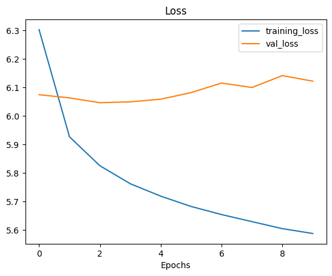

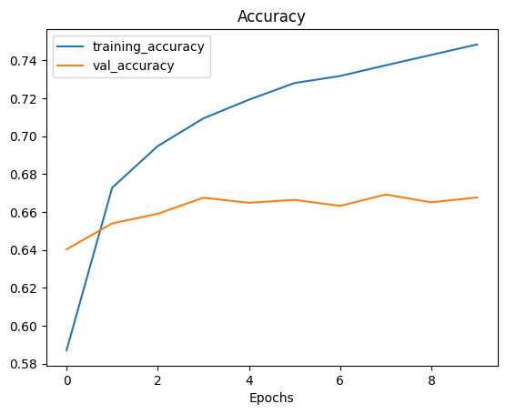

```python
plot_result_curves(model_Efficientnet_Dropout50_WD_model_history) # Plotting the result curves
```

#### **Observation**

The EfficientNet model with the weight decay factor in the loss function performs almost similar to the original EfficientNet model with a training accuracy of 74.84% and a validation accuracy of 66.77%. This also indicates the need of using additional layers in order to leverage the benifits of these techniques.

### Model 9: EfficientNet with Dense and Dropout layers

```python
model_Efficientnet_DenseDropout = tf.keras.Sequential([
    hub.KerasLayer(EfficientNet, trainable = False, input_shape = (250,250,3), name = 'EfficientNet_B0'), # EfficientNet_B0 Layer
    tf.keras.layers.Dense(512),                                                                           # Dense layer with 512 neurons
    tf.keras.layers.Dropout(0.25),                                                                        # Dropout layer with dropout factor of 0.25
    tf.keras.layers.Dense(256),                                                                           # Dense layer with 256 neurons
    tf.keras.layers.Dropout(0.25),                                                                        # Dropout layer with dropout factor of 0.25
    tf.keras.layers.Dense(101, activation = 'softmax', name = 'Output_layer')                             # Dense layer with 101 neurons for output
])

def custom_loss_with_weight_decay(weight_decay):    # Custom loss function
    def loss(y_true, y_pred):
        l2_reg = tf.add_n([tf.nn.l2_loss(var) for var in model.trainable_weights])
        return tf.reduce_mean(tf.losses.categorical_crossentropy(y_true, y_pred)) + weight_decay * l2_reg
    return loss

model_Efficientnet_DenseDropout.compile(
    optimizer = tf.keras.optimizers.Adam(learning_rate=0.001),           # Adam optimizer with learning rate 0.001
    loss = custom_loss_with_weight_decay(0.01),                          # Custom loss function with Categorical crossentropy loss and Weight decay factor of 0.01
    metrics = ['accuracy']                                               # Accuracy metric to be used for model evaluation
)

model_Efficientnet_DenseDropout.summary() # Printing the model summary

model_Efficientnet_DenseDropout_model_history = model_Efficientnet_DenseDropout.fit(train_data, validation_data=val_data, epochs = 10, verbose = 1) # Training the model
```

```
Model: "sequential_33"
_________________________________________________________________
 Layer (type)                Output Shape              Param #
=================================================================
 EfficientNet_B0 (KerasLayer  (None, 1000)             5330564
 )

 dense_42 (Dense)            (None, 512)               512512

 dropout_30 (Dropout)        (None, 512)               0

 dense_43 (Dense)            (None, 256)               131328

 dropout_31 (Dropout)        (None, 256)               0

 Output_layer (Dense)        (None, 101)               25957

=================================================================
Total params: 6,000,361
Trainable params: 669,797
Non-trainable params: 5,330,564
_________________________________________________________________
```

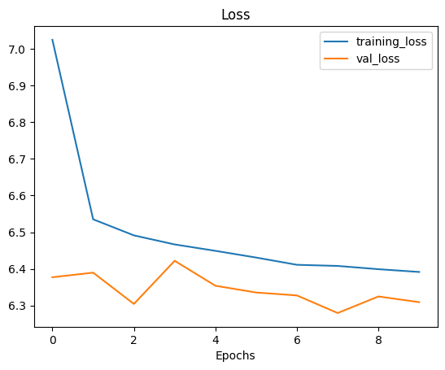

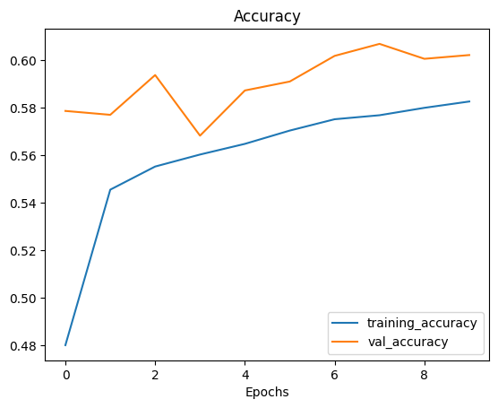

```python
plot_result_curves(model_Efficientnet_DenseDropout_model_history) # Plotting the result curves
```

#### **Observation**

We get a training accuracy of 58.25% and a validation accuracy of 60.21% when we add the Dense and Dropout layers. Also, as we can see in the graphs, the validation accuracy and loss are better than the training accuracy and loss respectively. Now, although the model didn't perform upto the expected accuracy, it still bolsters the fact that using Dropout layers certainly reduces the overfitting as the model performs better in validation as compared to training.

In the previous iteration, we observed that the trainable variation of the EfficientNet model had the highest training accuracy and the lowest validation accuracy. Therefore, it makes sense to use the techniques we learned to the variation to test if the model performs better.

```python
base_model = tf.keras.applications.EfficientNetB0(include_top=False)
base_model.trainable = False # Setting all the layers to non-trainable

for layer in base_model.layers[:-5]:
    layer.trainable = True # Setting last 5 layers to trainable

inputs = layers.Input(shape=(250, 250, 3), name="input_layer")              # Input layer with shape (250, 250, 3)
x = base_model(inputs)                                                      # EfficientNetB0 model layer with last 5 layers as trainable
x = layers.Dense(512) (x)                                                   # Dense layer with 512 neurons
x = layers.Dropout(0.5) (x)                                                 # Dropout layer with dropout factor of 0.5
x = layers.Dense(256) (x)                                                   # Dense layer with 256 neurons
x = layers.Dropout(0.5) (x)                                                 # Dropout layer with dropout factor of 0.5
x = layers.Flatten()(x)                                                     # Flatten layer
outputs = layers.Dense(101, activation="softmax", name="output_layer")(x)   # Final output layer with 101 neurons

trainable_model = tf.keras.Model(inputs, outputs) # Building the model
```

```python
trainable_model.compile(loss="categorical_crossentropy",               # Categorical crossentropy loss: Since the output label is assigned one-hot category encoding value in form of 0s and 1.
             optimizer=tf.keras.optimizers.Adam(learning_rate=0.0001), # Adam optimizer with learning rate 0.0001
             metrics=["accuracy"])                                     # Accuracy metric to be used for model evaluation

trainable_model.summary() # Printing the model summary

trainable_model_history = trainable_model.fit(train_data, validation_data=val_data, epochs=10) # Training the model
```

```
Model: "model_4"
_________________________________________________________________
 Layer (type)                Output Shape              Param #
=================================================================
 input_layer (InputLayer)    [(None, 250, 250, 3)]     0

 efficientnetb0 (Functional)  (None, None, None, 1280)  4049571

 dense_44 (Dense)            (None, 7, 7, 512)         655872

 dropout_32 (Dropout)        (None, 7, 7, 512)         0

 dense_45 (Dense)            (None, 7, 7, 256)         131328

 dropout_33 (Dropout)        (None, 7, 7, 256)         0

 flatten_11 (Flatten)        (None, 12544)             0

 output_layer (Dense)        (None, 101)               1267045

=================================================================
Total params: 6,103,816
Trainable params: 2,054,245
Non-trainable params: 4,049,571
_________________________________________________________________
```

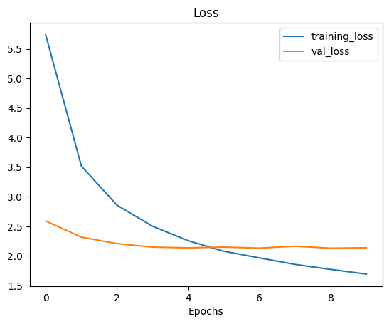

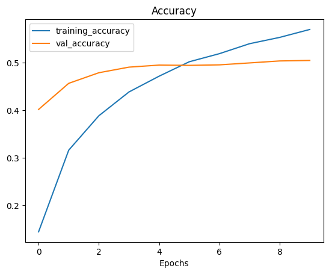

```python
plot_result_curves(trainable_model_history) # Plotting the result curves
```

#### **Observation**

Unfortunately, using the Dropout and Dense layers with trainable layers of the EfficientNet model does not provide any significant improvement in the training performance. However, the validation accuracy has certainly improved with a high factor after modifying the model parameters.

### Model 11: MobileNetV2 Model with GlobalAveragePooling2D layer

MobileNetV2 is a neural network architecture designed for mobile and embedded vision applications that require real-time performance, low latency, and low power consumption. It was developed by Google researchers and is an improvement over the original MobileNet architecture.

MobileNetV2 uses depthwise separable convolutions, which are a combination of depthwise convolutions and pointwise convolutions. Depthwise convolutions apply a single filter to each input channel, while pointwise convolutions use 1x1 filters to combine the output channels of the depthwise convolution. This approach reduces the number of parameters in the model and improves its computational efficiency, making it well-suited for mobile and embedded devices.

The GlobalAveragePooling2D layer helps to reduce the spatial dimensions of the input feature map while preserving the important features of the image. It does this by computing the average of each channel across the entire spatial extent of the feature map, resulting in a single value per channel. This pooling operation helps to make the model more robust to small variations and translations in the input image, as it aggregates the information from all locations of the feature map. It also reduces the number of parameters in the model, which can help prevent overfitting and improve the generalization performance of the model.

```python
model_MobileNet = tf.keras.Sequential([
    MobileNetV2(input_shape=(250,250,3),include_top=False, weights='imagenet'),                           # MobileNetV2 layer
    GlobalAveragePooling2D(),                                                                             # GlobalAveragePooling2D layer for global spatial pooling
    tf.keras.layers.Dense(101, activation = 'softmax', name = 'Output_layer')                             # Dense layer with 101 neurons for output
])

model_MobileNet.compile(
    optimizer = tf.keras.optimizers.Adam(),                              # Adam optimizer with learning rate 0.001
    loss = tf.keras.losses.CategoricalCrossentropy(),                    # Categorical crossentropy loss: Since the output label is assigned one-hot category encoding value in form of 0s and 1.
    metrics = ['accuracy']                                               # Accuracy metric to be used for model evaluation
)

model_MobileNet.summary() # Printing the model summary

model_MobileNet_model_history = model_MobileNet.fit(train_data, validation_data=val_data, epochs = 8, verbose = 1) # Training the model
```

```
WARNING:tensorflow:`input_shape` is undefined or non-square, or `rows` is not in [96, 128, 160, 192, 224]. Weights for input shape (224, 224) will be loaded as the default.
```

```
WARNING:tensorflow:`input_shape` is undefined or non-square, or `rows` is not in [96, 128, 160, 192, 224]. Weights for input shape (224, 224) will be loaded as the default.
```

```
Model: "sequential_34"
_________________________________________________________________
 Layer (type)                Output Shape              Param #
=================================================================
 mobilenetv2_1.00_224 (Funct  (None, 8, 8, 1280)       2257984
 ional)

 global_average_pooling2d_9   (None, 1280)             0
 (GlobalAveragePooling2D)

 Output_layer (Dense)        (None, 101)               129381

=================================================================
Total params: 2,387,365
Trainable params: 2,353,253
Non-trainable params: 34,112
_________________________________________________________________
```

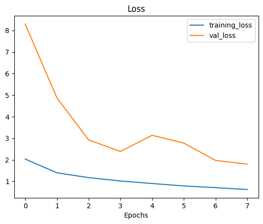

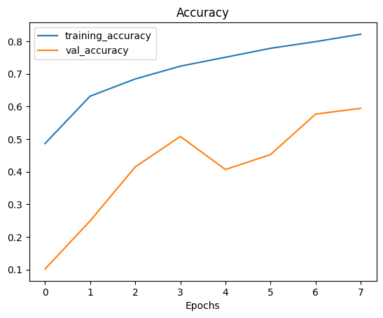

```python
plot_result_curves(model_MobileNet_model_history) # Plotting the result curves
```

### Model 12: MobileNet with additional layers

```python
base = MobileNetV2(input_shape=(224,224,3),include_top=False,weights='imagenet')       # MobileNetV2 layer
base.trainable = True                                                                  # Setting the MobileNetV2 layer to trainable
model = Sequential()
model.add(base)
model.add(GlobalAveragePooling2D())                                                    # GlobalAveragePooling2D layer for global spatial pooling
model.add(Dense(128, activation='relu'))                                               # Dense layer with 128 neurons
model.add(Dropout(0.5))                                                                # Dropout layer with 0.5 dropout rate
model.add(Dense(101, activation='softmax'))                                            # Dense layer with 101 neurons for output
opt = Adam(learning_rate=0.001)                                                        # Adam optimizer with learning rate = 0.001
model.compile(optimizer=opt,loss = 'categorical_crossentropy',metrics=['accuracy'])    # Compiling model with Categorical CrossEntropy loss function and Accuracy Metric
```

```python
reduce_lr = ReduceLROnPlateau(monitor = 'val_accuracy',patience = 1,verbose = 1)                          # ReduceLROnPlateau to reduce learning rate when a metric has stopped improving
early_stop = EarlyStopping(monitor = 'val_accuracy',patience = 5,verbose = 1,restore_best_weights = True) # EarlyStopping layer to stop training when val_accuracy has stopped improving.
```

```python
history = model.fit(train_data,
            epochs=10,
            validation_data = val_data,
            callbacks=[early_stop, reduce_lr])
```

[output not shown]

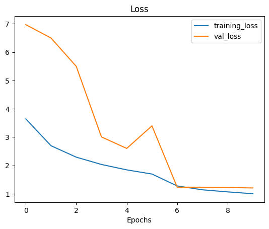

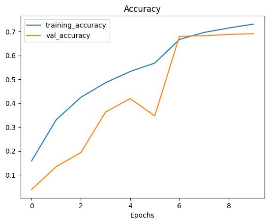

```python
plot_result_curves(history) # Plotting the result curves
```

### Conclusion

Following are the training and validation accuracies of the trained models

[output not shown]